# Recommender System for Movie Recommendations

By: Shouvik, Natalia, Shanya

Fall 2022

**[Click this Link to Access Project GitHub](https://github.com/Shouvik-7/Movie-recommender-in-R)**

NOTE: For successful execution of the code below, the user will require the following packages: `recommenderlab` `reshape2` `data.table` `ggplot2` `stringr` `superml` `tidyverse` `lsa` `tm` `wordcloud` `RCurl` `lemon`

Today, easy-access, streaming services offer immediate gratification through an on-demand, personalized viewing experience. This is one of many recommend systems the average individual encounters on a daily bases… but how do they work? The following report, offers a small glimpse into the logic behind these complex customization features.

The code and written walk-through below constructs a recommender system for movies using the well known, TMDB Movies dataset. This data was obtained from Kaggle and cleaned in Python. All preprocessing steps that are relevant to this project were included below. For the purpose of creating a clear, general framework for much more complex recommender systems, a fairly simple dataset was chosen. The selected dataset contains 4806 objects (each representing a movie) with 7 columns containing descriptive characteristic of each movie.

## Loading the data

For reproducability without the need for downloading or transferring data, we will import the movies dataset directly from a public GitHub repository. After getting the raw data url we will use the `read.csv` function to import the data into the notebook. We use the `head` function to show only the top few rows to confirm the data is in the expected form.

NOTE: for all other progress checking print-outs, we will only display 1-2 rows to reduce crowding and increase readability

```r
gh_url <- getURL("https://raw.githubusercontent.com/Shouvik-7/Movie-recommender-in-R/main/movies.csv")
movie_data <- read.csv(text = gh_url)
movie_data <- data.frame(movie_data)
head(movie_data)
```

| movie_id | title | overview | genres | keywords | cast | crew |
| --- | --- | --- | --- | --- | --- | --- |
| 19995 | Avatar | In the 22nd century, a paraplegic Marine is dispatched to the moon Pandora on a unique mission, but becomes torn between following orders and protecting an alien civilization. | Action Adventure Fantasy ScienceFiction | cultureclash future spacewar spacecolony society spacetravel futuristic romance space alien tribe alienplanet cgi marine soldier battle loveaffair antiwar powerrelations mindandsoul 3d | SamWorthington ZoeSaldana SigourneyWeaver | JamesCameron |
| 285 | Pirates of the Caribbean: At World’s End | Captain Barbossa, long believed to be dead, has come back to life and is headed to the edge of the Earth with Will Turner and Elizabeth Swann. But nothing is quite as it seems. | Adventure Fantasy Action | ocean drugabuse exoticisland eastindiatradingcompany loveofone’slife traitor shipwreck strongwoman ship alliance calypso afterlife fighter pirate swashbuckler aftercreditsstinger | JohnnyDepp OrlandoBloom KeiraKnightley | GoreVerbinski |
| 206647 | Spectre | A cryptic message from Bond’s past sends him on a trail to uncover a sinister organization. While M battles political forces to keep the secret service alive, Bond peels back the layers of deceit to… | Action Adventure Crime | spy basedonnovel secretagent sequel mi6 britishsecretservice unitedkingdom | DanielCraig ChristophWaltz LéaSeydoux | SamMendes |
| 49026 | The Dark Knight Rises | Following the death of District Attorney Harvey Dent, Batman assumes responsibility for Dent’s crimes to protect the late attorney’s reputation and is subsequently hunted by the Gotham City Police Dep… | Action Crime Drama Thriller | dccomics crimefighter terrorist secretidentity burglar hostagedrama timebomb gothamcity vigilante cover-up superhero villainess tragichero terrorism destruction catwoman catburglar imax flood criminal… | ChristianBale MichaelCaine GaryOldman | ChristopherNolan |
| 49529 | John Carter | John Carter is a war-weary, former military captain who’s inexplicably transported to the mysterious and exotic planet of Barsoom (Mars) and reluctantly becomes embroiled in an epic conflict. It’s a w… | Action Adventure ScienceFiction | basedonnovel mars medallion spacetravel princess alien steampunk martian escape edgarriceburroughs alienrace superhumanstrength marscivilization swordandplanet 19thcentury 3d | TaylorKitsch LynnCollins SamanthaMorton | AndrewStanton |
| 559 | Spider-Man 3 | The seemingly invincible Spider-Man goes up against an all-new crop of villain – including the shape-shifting Sandman. While Spider-Man’s superpowers are altered by an alien organism, his alter eg… | Fantasy Action Adventure | dualidentity amnesia sandstorm loveofone’slife forgiveness spider wretch deathofafriend egomania sand narcism hostility marvelcomic sequel superhero revenge | TobeyMaguire KirstenDunst JamesFranco | SamRaimi |

## Selecting relevant features

The above data contains many unneeded features such as characteristics and movie synopsis. First we isolate the necesary attributes for a simplistic movie recommend system. Note that recommender systems can range in complexity based on the amount of attributes considered, however the following system offers a simplistic, general example of the basic system framework. We use the `select` function from the `tidyverse` package to select the features that are important to constructing the recommender system. In this case, the features of interest are `movie_id`, `title`, `genres`, `keywords`, `cast`, `crew`.

```r
movie_data <- movie_data %>% select(,c('movie_id','title','genres','keywords','cast','crew'))
```

| movie_id | title | genres | keywords | cast | crew |
| --- | --- | --- | --- | --- | --- |
| 19995 | Avatar | Action Adventure Fantasy ScienceFiction | cultureclash future spacewar spacecolony society spacetravel futuristic romance space alien tribe alienplanet cgi marine soldier battle loveaffair antiwar powerrelations mindandsoul 3d | SamWorthington ZoeSaldana SigourneyWeaver | JamesCameron |

## Creating tags

Next, we create condense all of the attributes of interest into a new, single column called `tags`. This column now contains a concatenation of the features `genres`, `keywords`, `cast`, `crew`, separated by a space (” “).

```r
movie_data$tags <- paste(movie_data$genres,movie_data$keywords,movie_data$cast,movie_data$crew,sep=" ")
```

Additionally, to ensure consistency, all of the tags should be lower case. This prevents accidents such as failure to recognize matching values due to difference in case sensitivity. For this manipulation we use the functions `sapply` from `tidyverse` package and `tolower`applied to the `tags` column.

| movie_id | title | genres | keywords | cast | crew | tags |
| --- | --- | --- | --- | --- | --- | --- |
| 19995 | Avatar | Action Adventure Fantasy ScienceFiction | cultureclash future spacewar spacecolony society spacetravel futuristic romance space alien tribe alienplanet cgi marine soldier battle loveaffair antiwar powerrelations mindandsoul 3d | SamWorthington ZoeSaldana SigourneyWeaver | JamesCameron | action adventure fantasy sciencefiction cultureclash future spacewar spacecolony society spacetravel futuristic romance space alien tribe alienplanet cgi marine soldier battle loveaffair antiwar power… |
| 285 | Pirates of the Caribbean: At World’s End | Adventure Fantasy Action | ocean drugabuse exoticisland eastindiatradingcompany loveofone’slife traitor shipwreck strongwoman ship alliance calypso afterlife fighter pirate swashbuckler aftercreditsstinger | JohnnyDepp OrlandoBloom KeiraKnightley | GoreVerbinski | adventure fantasy action ocean drugabuse exoticisland eastindiatradingcompany loveofone’slife traitor shipwreck strongwoman ship alliance calypso afterlife fighter pirate swashbuckler aftercreditsstin… |

## Vectorizing the data to a sparse matrix

After pre-processing the data, we can generate a bag of words model and return a sparse matrix consisting of token counts. This task is made simple by using the `CounterVectorize$new()` function with the following arguments:

**`min_df`: numeric** i.e. When building the vocabulary ignore terms that have a document frequency strictly lower than the given threshold (value lies between 0 and 1)

**`max_df`: numeric** i.e. When building the vocabulary ignore terms that have a document frequency strictly higher than the given threshold (value lies between 0 and 1)

**`max_features`: integer** i.e. Build a vocabulary that only considers the top max_features ordered by term frequency across the corpus

**`ngram_range`: vector** i.e. The lower and upper boundary of the range of n-values for different word n-grams or character n-grams to be extracted. All values of n such such that min_n <= n <= max_n will be used. For example an ngram_range of c(1, 1) means only unigrams, c(1, 2) means unigrams and bigrams, and c(2, 2) means only bigrams.

**`regex`: character** i.e. regex expression to use for text cleaning.

**`remove_stopwords`: list** i.e. A list of stopwords to use. By default it uses its inbuilt list of standard English stopwords

**`split`: character** i.e Splitting criteria for strings (default: ” “)

**`lowercase`: logical** i.e. convert all characters to lowercase before tokenizing (default: TRUE)

```r
cfv <- CountVectorizer$new(max_features = 500, remove_stopwords = TRUE)
# generate the matrix
cf_mat <- cfv$fit_transform(movie_data$tags)
#head(cf_mat)
```

Now we should have a sparse matrix consisting of token counts. The print out of the above matrix has been excluded do to the fact that it is cumbersome and difficult to read. However, to see the matrix in greater detail, feel free to un-comment the print out function in the above code chunk. The following code checks the dimension of this matrix using the `dim` function.

```r
dim(cf_mat)
```

```
## [1] 4806  500
```

Next, we implement the `cosine()` function to calculate the distance between two vector points.

```r
cosine(cf_mat[1,],cf_mat[3,])
```

```
##           [,1]
## [1,] 0.1961161
```

## Creating a function to Recommend movies

```r
recommend <- function(moviename) {
  mindex <- which(movie_data$title==moviename)
  mvector <- cf_mat[mindex,]
  max1 = 0
  index1 = 0
  max2 = 0
  index2 = 0
  max3 = 0
  index3 = 0
  max4 = 0
  index4 = 0
  max5 = 0
  index5 = 0
  for(row in 1:nrow(cf_mat)) {

    val = cosine(mvector,cf_mat[row,])

    if(is.na(val)) {
      max1 = max1
    }
    else if(val > max1 & val<1) {
      max1 = val
      index1 = row
    }
    else if(val > max2 & val<1) {
      max2 = val
      index2 = row
    }
    else if(val > max3 & val<1) {
      max3 = val
      index3 = row
    }
    else if(val > max4 & val<1) {
      max4 = val
      index4 = row
    }
    else if(val > max5 & val<1) {
      max5 = val
      index5 = row
    }
  }

  return(do.call("rbind", list(movie_data[index1,], movie_data[index2,], movie_data[index3,], movie_data[index4,], movie_data[index5,])))

}
```

## Testing the `recommend` function

```r
recommend('Batman Begins')
```

|  | movie_id | title | genres | keywords | cast | crew | tags |
| --- | --- | --- | --- | --- | --- | --- | --- |
| 66 | 155 | The Dark Knight | Drama Action Crime Thriller | dccomics crimefighter secretidentity scarecrow sadism chaos gothamcity vigilante joker superhero basedoncomicbook tragichero organizedcrime criminalmastermind districtattorney imax supervillain superp… | ChristianBale HeathLedger AaronEckhart | ChristopherNolan | drama action crime thriller dccomics crimefighter secretidentity scarecrow sadism chaos gothamcity vigilante joker superhero basedoncomicbook tragichero organizedcrime criminalmastermind districtattor… |
| 211 | 415 | Batman & Robin | Action Crime Fantasy | doublelife dccomics dualidentity crimefighter fictionalplace gothamcity superhero creditcard superpowers | GeorgeClooney ChrisO’Donnell ArnoldSchwarzenegger | JoelSchumacher | action crime fantasy doublelife dccomics dualidentity crimefighter fictionalplace gothamcity superhero creditcard superpowers georgeclooney chriso’donnell arnoldschwarzenegger joelschumacher |
| 3331 | 312113 | Black November | Drama Action Crime |  | RazaaqAdoti SarahWayneCallies MickeyRourke | JetaAmata | drama action crime razaaqadoti sarahwaynecallies mickeyrourke jetaamata |
| 4642 | 378237 | Amidst the Devil’s Wings | Drama Action Crime |  |  |  | drama action crime |
| 4106 | 7873 | Harsh Times | Crime Drama Thriller Action | watchingamovie playingpool vinegar | ChristianBale FreddyRodrÃguez EvaLongoria | DavidAyer | crime drama thriller action watchingamovie playingpool vinegar christianbale freddyrodrãguez evalongoria davidayer |

## Visualizing data set

To see what words are most commonly found in the tags, we use the `colSums` function followed by `cbind` to join the frequency with its associated word.

```r
freq <- colSums(cf_mat)
freqdf <- data.frame(freq)
freqdf2 <- cbind(word = rownames(freqdf), freqdf)
head(freqdf2)
```

|  | word | freq |
| --- | --- | --- |
| drama | drama | 2310 |
| comedy | comedy | 1748 |
| thriller | thriller | 1278 |
| action | action | 1159 |
| romance | romance | 918 |
| adventure | adventure | 810 |

Lastly, we visualize the data above to offer non-technical insight into the bases of the output recommendations. This can be done by generating a wordcloud through the `wordcloud` function from the `tm` package. While this might seem trivial, proper transparency is a crucial responsibility for data scientists.

In today’s modern age, people are quick to blind trust in technology. However, many recommendation systems are black boxes for the general public. While the technical breakdown above holds zero relevance to most users, non-technical transparency (such as the visualization below) provides some level of understanding as to what premise the recommendations are made on.

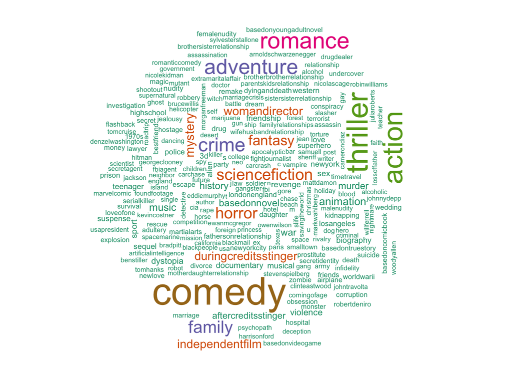

```r
wordcloud(freqdf2$word, freqdf$freq, max.words = 250, colors= brewer.pal(8, "Dark2"))
```

Another convenient way to express the data from `freqdf2` is to use a barplot from base R using the `barplot` function.

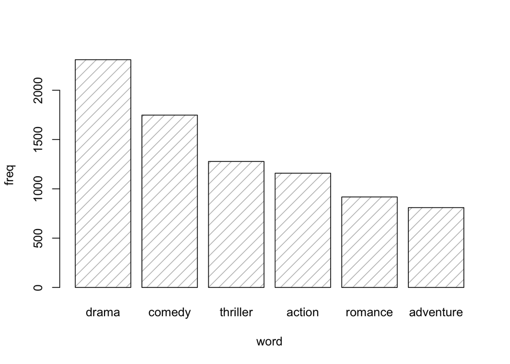

```r
barplot(head(freqdf2)$freq, names.arg=head(freqdf2)$word, xlab="word",ylab="freq",density=10)
```

## Acknowledgemnt of Bias in Recommender Systems

Many recommendation systems hold far greater weight than simple movie suggestions, but transparency and acknowledgment combat biases and possible repercussions that inevitably result from human-made models. In the creation of any recommender system, the architect makes some decision(s) on how to formulate relationships that ultimately lead to recommendations. This inevitably introduces bias. Therefore, as stated above, greater transparency and the inclusion of confidence metrics helps in reducing potential harm.